# Thera Bank Personal Loan Campaign

This case is about a bank (Thera Bank) whose management wants to explore ways of converting its liability customers to personal loan customers (while retaining them as depositors). A campaign that the bank ran last year for liability customers showed a healthy conversion rate of over 9% success. This has encouraged the retail marketing department to devise campaigns with better target marketing to increase the success ratio with a minimal budget.

#### Domain

Banking

## Introduction

The data that has been provided consists of banking information for 5000 customers of Thera Bank. The goal of this project is to help the retail marketing department to devise new campaigns for their liability customers.

The dataset contains data on 5000 customers. The data include customer demographic information (age, income, etc.), the customer's relationship with the bank (mortgage, securities account, etc.), and the customer response to the last personal loan campaign (Personal Loan). Among these 5000 customers, only 480 (= 9.6%) accepted the personal loan that was offered to them in the earlier campaign.

The classification goal is **to predict the likelihood of a liability customer buying personal loans**.

## Criterias

### 1. Statistical Summary and Null value check

#### Import the datasets and libraries, check datatype, statistical summary, shape, null values or incorrect imputation

```python
import warnings
warnings.filterwarnings('ignore')

import os,sys
import numpy as np
import pandas as pd
import matplotlib.pyplot as plt
import seaborn as sns
from IPython.core.display import display, HTML
from sklearn.linear_model import LogisticRegression
from sklearn.metrics import classification_report, confusion_matrix, recall_score, precision_score, f1_score, roc_auc_score,accuracy_score
from sklearn.model_selection import train_test_split
from scipy import stats
import statsmodels.api as sm
 #!pip install yellowbrick
from yellowbrick.classifier import ClassificationReport, ROCAUC
from sklearn.model_selection import GridSearchCV

%matplotlib inline

# Increase cell width
display(HTML("<style>.container { width:98% !important; }</style>"))

# Update seaborn default style
sns.set_style(style='darkgrid')
sns.set_palette("muted")
```

```python
cust_df = pd.read_csv("Bank_Personal_Loan_Modelling.csv")
print("")
print("Customers Data")
print("**************")
print("")
display(HTML(cust_df.head(10).to_html()))
```

```
Customers Data
**************
```

|  | ID | Age | Experience | Income | ZIP Code | Family | CCAvg | Education | Mortgage | Personal Loan | Securities Account | CD Account | Online | CreditCard |
| --- | --- | --- | --- | --- | --- | --- | --- | --- | --- | --- | --- | --- | --- | --- |
| 0 | 1 | 25 | 1 | 49 | 91107 | 4 | 1.6 | 1 | 0 | 0 | 1 | 0 | 0 | 0 |
| 1 | 2 | 45 | 19 | 34 | 90089 | 3 | 1.5 | 1 | 0 | 0 | 1 | 0 | 0 | 0 |
| 2 | 3 | 39 | 15 | 11 | 94720 | 1 | 1.0 | 1 | 0 | 0 | 0 | 0 | 0 | 0 |
| 3 | 4 | 35 | 9 | 100 | 94112 | 1 | 2.7 | 2 | 0 | 0 | 0 | 0 | 0 | 0 |
| 4 | 5 | 35 | 8 | 45 | 91330 | 4 | 1.0 | 2 | 0 | 0 | 0 | 0 | 0 | 1 |
| 5 | 6 | 37 | 13 | 29 | 92121 | 4 | 0.4 | 2 | 155 | 0 | 0 | 0 | 1 | 0 |
| 6 | 7 | 53 | 27 | 72 | 91711 | 2 | 1.5 | 2 | 0 | 0 | 0 | 0 | 1 | 0 |
| 7 | 8 | 50 | 24 | 22 | 93943 | 1 | 0.3 | 3 | 0 | 0 | 0 | 0 | 0 | 1 |
| 8 | 9 | 35 | 10 | 81 | 90089 | 3 | 0.6 | 2 | 104 | 0 | 0 | 0 | 1 | 0 |
| 9 | 10 | 34 | 9 | 180 | 93023 | 1 | 8.9 | 3 | 0 | 1 | 0 | 0 | 0 | 0 |

```python
print("")
print("Describing Customers")
print("********************")
print("")
print("Customers -- Info")
print(cust_df.info())
print("")
print("Customers -- Shape")
print(cust_df.shape)
print("")
print("Customer -- Describe")
display(HTML(cust_df.describe().T.to_html()))
print("")
print("Customer -- IsNull")
print(cust_df.isnull().sum())
print("")
print("Customer - IsNa")
print(cust_df.isna().sum())
print("")
```

```
Describing Customers

Customers -- Info
<class 'pandas.core.frame.DataFrame'>
RangeIndex: 5000 entries, 0 to 4999
Data columns (total 14 columns):
 #   Column              Non-Null Count  Dtype
---  ------              --------------  -----
 0   ID                  5000 non-null   int64
 1   Age                 5000 non-null   int64
 2   Experience          5000 non-null   int64
 3   Income              5000 non-null   int64
 4   ZIP Code            5000 non-null   int64
 5   Family              5000 non-null   int64
 6   CCAvg               5000 non-null   float64
 7   Education           5000 non-null   int64
 8   Mortgage            5000 non-null   int64
 9   Personal Loan       5000 non-null   int64
 10  Securities Account  5000 non-null   int64
 11  CD Account          5000 non-null   int64
 12  Online              5000 non-null   int64
 13  CreditCard          5000 non-null   int64
dtypes: float64(1), int64(13)
memory usage: 547.0 KB
None

Customers -- Shape
(5000, 14)

Customer -- Describe
```

|  | count | mean | std | min | 25% | 50% | 75% | max |
| --- | --- | --- | --- | --- | --- | --- | --- | --- |
| ID | 5000.0 | 2500.500000 | 1443.520003 | 1.0 | 1250.75 | 2500.5 | 3750.25 | 5000.0 |
| Age | 5000.0 | 45.338400 | 11.463166 | 23.0 | 35.00 | 45.0 | 55.00 | 67.0 |
| Experience | 5000.0 | 20.104600 | 11.467954 | -3.0 | 10.00 | 20.0 | 30.00 | 43.0 |
| Income | 5000.0 | 73.774200 | 46.033729 | 8.0 | 39.00 | 64.0 | 98.00 | 224.0 |
| ZIP Code | 5000.0 | 93152.503000 | 2121.852197 | 9307.0 | 91911.00 | 93437.0 | 94608.00 | 96651.0 |
| Family | 5000.0 | 2.396400 | 1.147663 | 1.0 | 1.00 | 2.0 | 3.00 | 4.0 |
| CCAvg | 5000.0 | 1.937938 | 1.747659 | 0.0 | 0.70 | 1.5 | 2.50 | 10.0 |
| Education | 5000.0 | 1.881000 | 0.839869 | 1.0 | 1.00 | 2.0 | 3.00 | 3.0 |
| Mortgage | 5000.0 | 56.498800 | 101.713802 | 0.0 | 0.00 | 0.0 | 101.00 | 635.0 |
| Personal Loan | 5000.0 | 0.096000 | 0.294621 | 0.0 | 0.00 | 0.0 | 0.00 | 1.0 |
| Securities Account | 5000.0 | 0.104400 | 0.305809 | 0.0 | 0.00 | 0.0 | 0.00 | 1.0 |
| CD Account | 5000.0 | 0.060400 | 0.238250 | 0.0 | 0.00 | 0.0 | 0.00 | 1.0 |
| Online | 5000.0 | 0.596800 | 0.490589 | 0.0 | 0.00 | 1.0 | 1.00 | 1.0 |
| CreditCard | 5000.0 | 0.294000 | 0.455637 | 0.0 | 0.00 | 0.0 | 1.00 | 1.0 |

```
Customer -- IsNull
ID                    0
Age                   0
Experience            0
Income                0
ZIP Code              0
Family                0
CCAvg                 0
Education             0
Mortgage              0
Personal Loan         0
Securities Account    0
CD Account            0
Online                0
CreditCard            0
dtype: int64

Customer - IsNa
ID                    0
Age                   0
Experience            0
Income                0
ZIP Code              0
Family                0
CCAvg                 0
Education             0
Mortgage              0
Personal Loan         0
Securities Account    0
CD Account            0
Online                0
CreditCard            0
dtype: int64
```

##### Observation:

- There are **no** outright null values.
- **Age**: Average age of a customer with the bank, is 45
- **Experience**: Experience column has minimum of -3. This does not look right. This could be because of invalid data entry. This will need to be fixed.
- **ZIP Code**: Takes numerical value, but not quantitative. Eg: Sum of two zip codes is not meaningful.
- **Mortgage**: Atleast 50% of the customers dont have a mortgage with the bank.
- **Securities Account**: Atleast 75% of the customers dont have a Securities Account with the bank.
- **CD Account**: Atleast 75% of the customers dont have a CD Account with the bank.
- **Online**: 50% of the customers have Online access to their account with the bank.
- **CreditCard**: 50% of the customer dont have a credit card with the bank.
- Some of the categorical columns are showing up as numerical. We will convert them.

### 2. EDA

#### Study the data distribution in each attribute and target variable, share your findings

#### Number of unique in each column?

```python
print("Number of unique values in each column")
print("**************************************")
cust_df.nunique()
```

```
Number of unique values in each column
```

```
ID                    5000
Age                     45
Experience              47
Income                 162
ZIP Code               467
Family                   4
CCAvg                  108
Education                3
Mortgage               347
Personal Loan            2
Securities Account       2
CD Account               2
Online                   2
CreditCard               2
dtype: int64
```

##### Observation

- ZIP Code: Takes numerical value, but not quantitative. Eg: Sum of two zip codes is not meaningful.
- Family: Though it takes only one of 4 values in this data set, its still quantitative, because it has a numerical value with meaningful order and equal intervals

#### Number of people with zero mortgage?

```python
print("Number of customers with zero mortgage                                : {0}".format(cust_df[cust_df["Mortgage"] == 0].shape[0]))
print("Percentage of customers with zero mortage                             : {0:0.2f}%".format((cust_df[cust_df["Mortgage"] == 0].shape[0] / cust_df.shape[0]) * 100))
print("Percentage of customers who accepted personal loan, with zero mortage : {0:0.2f}%".format(cust_df.loc[(cust_df['Personal Loan'] == 1) & (cust_df["Mortgage"] == 0)].shape[0] / cust_df.loc[cust_df['Personal Loan'] == 1].shape[0] * 100, "%"))
```

```
Number of customers with zero mortgage                                : 3462
Percentage of customers with zero mortage                             : 69.24%
Percentage of customers who accepted personal loan, with zero mortage : 65.00%
```

##### Observation:

Since 65% of customers who accepted the personal loan, had no mortage, this is an important parameter and we cannot remove it

#### Number of people with zero credit card spending per month?

```python
# Number of people with zero credit card spending per month ?
print("Number of customers with zero credit card spending per month                                 : {0}".format(cust_df[cust_df["CCAvg"] == 0].shape[0]))
print("Percentage of customers with zero credit card spending per month                             : {0:0.2f}%".format((cust_df[cust_df["CCAvg"] == 0].shape[0] / cust_df.shape[0]) * 100))
print("Percentage of customers who accepted personal loan, with zero credit card spending per month : {0:0.2f}%".format(cust_df.loc[(cust_df['Personal Loan'] == 1) & (cust_df["CCAvg"] == 0)].shape[0] / cust_df.loc[cust_df['Personal Loan'] == 1].shape[0] * 100))
```

```
Number of customers with zero credit card spending per month                                 : 106
Percentage of customers with zero credit card spending per month                             : 2.12%
Percentage of customers who accepted personal loan, with zero credit card spending per month : 0.21%
```

##### Obervation

Of the people who accepted the personal loan, only 0.21% of them did not have any credit card spending. So this is an important paramter and cannot be removed.

#### Value counts of all categorical columns.

```python
# Get value counts for categorical columns
categorical_columns = ["ZIP Code", "Education", "Personal Loan", "Securities Account", "CD Account", "Online", "CreditCard"]
numeric_columns = ["Age", "Experience", "Income", "Family", "CCAvg", "Mortgage"]

print("Checking value count of category columns")
print("****************************************")
print("")
for i in categorical_columns:
    print(cust_df[i].value_counts())
    print()
```

```
Checking value count of category columns

94720    169
94305    127
95616    116
90095     71
93106     57
        ...
96145      1
94970      1
94598      1
90068      1
94087      1
Name: ZIP Code, Length: 467, dtype: int64

1    2096
3    1501
2    1403
Name: Education, dtype: int64

0    4520
1     480
Name: Personal Loan, dtype: int64

0    4478
1     522
Name: Securities Account, dtype: int64

0    4698
1     302
Name: CD Account, dtype: int64

1    2984
0    2016
Name: Online, dtype: int64

0    3530
1    1470
Name: CreditCard, dtype: int64
```

#### Univariate and Bivariate

```python
# Let looks at the univariate plots for the numeric columns to see their distribution
box_plot_columns = ["Age", "Experience", "Family"]
dist_plot_columns = ["Income", "CCAvg", "Mortgage"]
count_plot_columns = ["Education", "Securities Account", "CD Account", "Online", "CreditCard"]
```

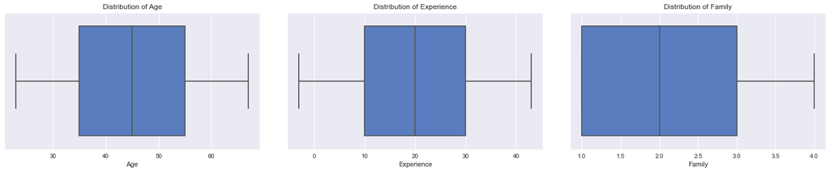

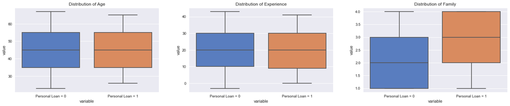

```python
num_plots = len(box_plot_columns)
total_cols = 3
total_rows = 1
fig, axs = plt.subplots(nrows=total_rows, ncols=total_cols, figsize=(20, 5))
for i, var in enumerate(box_plot_columns):
    pos = i % total_cols
    ax = sns.boxplot(cust_df[var], ax=axs[pos])
    ax.set_title("Distribution of {0}".format(var))
fig.tight_layout(pad=4.5)
plt.show();

fig, axs = plt.subplots(nrows=total_rows, ncols=total_cols, figsize=(20, 5))
for i, var in enumerate(box_plot_columns):
    not_taken_personal_loan = cust_df[cust_df["Personal Loan"] == 0][var]
    taken_personal_loan = cust_df[cust_df["Personal Loan"] == 1][var]
    df = pd.DataFrame({'Personal Loan = 0': not_taken_personal_loan, 'Personal Loan = 1': taken_personal_loan})
    pos = i % total_cols
    ax = sns.boxplot(x="variable", y="value", data=pd.melt(df), ax=axs[pos])
    ax.set_title("Distribution of {0}".format(var))
fig.tight_layout(pad=4.5)
plt.show();
```

##### Observation

- **Age** and **Experience** seem to be normally distributed. Mean Age is around 45 and Mean Experience is around 20 years
- **Family** seems to have a positive skew with mean around family size of 2
- When observed along with Personal Loan information, we see **Age** and **Experience** compare the same way.
- **Family** when compared along with Personal Loan information, shows that the mean family size was 3 for customers who accepted the Personal Loan
- Also all **Family** sizes have taken Personal Loan.

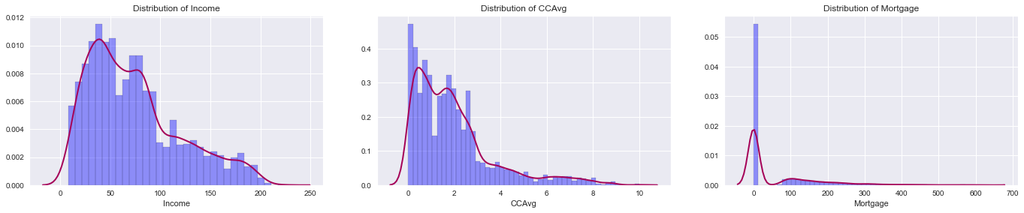

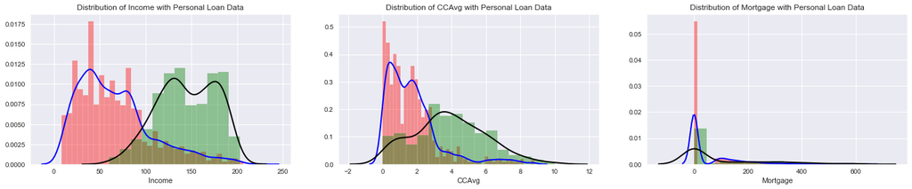

```python
num_plots = len(dist_plot_columns)
total_cols = 3
total_rows = 1
fig, axs = plt.subplots(nrows=total_rows, ncols=total_cols, figsize=(20, 5))
for i, var in enumerate(dist_plot_columns):
    pos = i % total_cols
    ax = sns.distplot(cust_df[var], color="blue", kde_kws={"color": "m", "lw": 2}, hist_kws={'edgecolor':'black'}, ax=axs[pos])
    ax.set_title("Distribution of {0}".format(var))
fig.tight_layout(pad=4.5)
plt.show();

fig, axs = plt.subplots(nrows=total_rows, ncols=total_cols, figsize=(20, 5))
for i, var in enumerate(dist_plot_columns):
    not_taken_personal_loan = cust_df[cust_df["Personal Loan"] == 0][var]
    taken_personal_loan = cust_df[cust_df["Personal Loan"] == 1][var]
    pos = i % total_cols
    ax = sns.distplot(not_taken_personal_loan, color="red", kde_kws={"color": "blue", "lw": 2}, ax=axs[pos])
    ax = sns.distplot(taken_personal_loan, color="green", kde_kws={"color": "black", "lw": 2}, ax=axs[pos])
    ax.set_title("Distribution of {0} with Personal Loan Data".format(var))
fig.tight_layout(pad=4.5)
plt.show();
```

##### Observation

- **Income**, **CCAvg** and **Mortgage** are positively skewed
- More number of customer have zero **Mortgage**
- When compared along with Personal Loan information, customers with higher **Income** seem to have accepted the Personal Loan
- Also customers with higher **CCAvg** also accepted Personal Loan

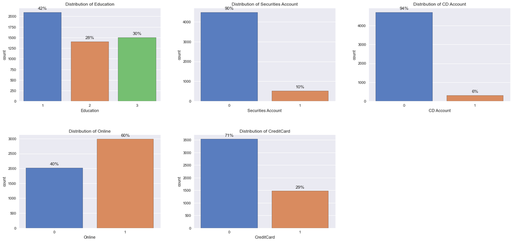

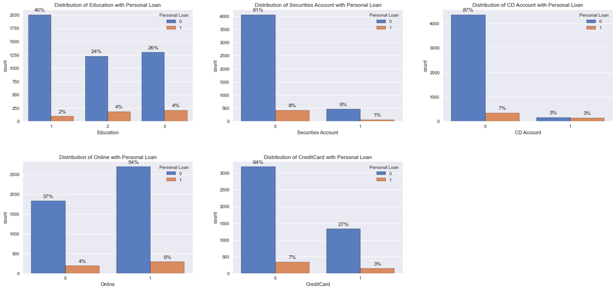

```python
num_plots = len(count_plot_columns)
total_cols = 3
total_rows = 2
fig, axs = plt.subplots(nrows=total_rows, ncols=total_cols, figsize=(20, 10))
for i, var in enumerate(count_plot_columns):
    row = i//total_cols
    pos = i % total_cols
    ax = sns.countplot(cust_df[var], edgecolor="black", ax=axs[row][pos])
    total = len(cust_df[var])
    for p in ax.patches:
        percentage = '{:.0f}%'.format(100 * p.get_height()/total)
        x = p.get_x() + 0.4
        y = p.get_y() + p.get_height()
        ax.annotate(percentage, (x,y), size = 12, ha = 'center', va = 'center', xytext = (0, 10), textcoords = 'offset points')
    ax.set_title("Distribution of {0}".format(var))
axs[1,2].set_axis_off()
fig.tight_layout(pad=4.5)
plt.show();


fig, axs = plt.subplots(nrows=total_rows, ncols=total_cols, figsize=(20, 10))
for i, var in enumerate(count_plot_columns):
    row = i//total_cols
    pos = i % total_cols
    ax = sns.countplot(x=var, hue="Personal Loan", data=cust_df, edgecolor="black", ax=axs[row][pos])
    total = len(cust_df[var])
    for p in ax.patches:
        percentage = '{:.0f}%'.format(100 * p.get_height()/total)
        x = p.get_x() + 0.2
        y = p.get_y() + p.get_height()
        ax.annotate(percentage, (x,y), size = 12, ha = 'center', va = 'center', xytext = (0, 10), textcoords = 'offset points')
    ax.set_title("Distribution of {0} with Personal Loan".format(var))
axs[1,2].set_axis_off()
fig.tight_layout(pad=4.5)
plt.show();
```

##### Observation

- **Education** - Of the customers: 42% are Undergraduates, 28% are Graduates and 30% have Advanced/Professional Education Levels
- **Securities Account** - 90% of the customers *dont* have a Securities Account with the bank.
- **CD Account** - 94% of the customers *dont* have a CD Account with the bank.
- **Online** - 60% of the customers use Internet Banking Facilities
- **CreditCard** - 71% of the customers dont have a Credit Card with this bank.

When compared along with Personal Loan information:

- **Education** - 4% of customer who are Graduates or with Advanced/Professional Education Levels accepted the Personal Loan. So people with higher education level seem to accept Personal Loans more.
- **Securities Account** - 8% of customers without Securities Account accepted the Personal Loan
- **CD Account** - 7% of customers without a CD Account accepted the Personal Loan
- **Online** - 6% of customers using Internet Banking Facilities accepted the Personal Loan
- **CreditCard** - 7% of customers without Credit Card from this bank, accepted the Personal Loan

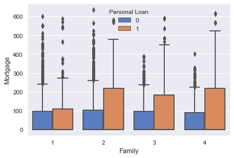

```python
# Lets look at some of the bivariate comparisons

# Do families with Mortage, take Personal Loan?

sns.boxplot(x="Family", y="Mortgage", hue="Personal Loan", data=cust_df)
plt.show();
```

##### Observation

- Customer will all **Family** sizes take Personal Loan. There doesnt seem to be a perference.
- Also it looks like **Families** with higher **Mortgage** have higher probability of accepting a Personal Loan

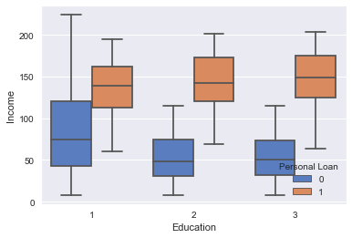

```python
# Does Education and Income affect the probablity of taking Personal Loan

sns.boxplot(x="Education", y="Income", hue="Personal Loan", data=cust_df)
plt.show();
```

##### Observation

- All **Education** levels who accepted Personal Loan, have around the same mean **Income**
- This further proves, people with higher **Income** have higher probability of accepting a Personal Loan

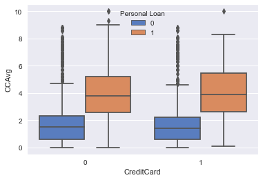

```python
# Does having a credit card or CCAvg influence taking Personal Loan?

sns.boxplot(x="CreditCard", y="CCAvg", hue="Personal Loan", data=cust_df)
plt.show();
```

##### Observation

- Regardless of whether the customer owns a credit card from this bank, higher the **CCAvg** higher the probability of taking a Personal Loan

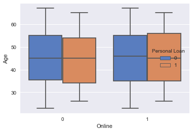

```python
# Does Age and having Internet Banking Facilities, access influence taking a Personal Loan
sns.boxplot(x="Online", y="Age", hue="Personal Loan", data=cust_df)
plt.show();
```

##### Observation

- Regardless of having access to Internet Banking Facilities, customers in the age range 35-55 seem have a higher probability of accepting Personal Loan

```python
# Lets check the correlation between the columns
correlation = cust_df.corr()
display(HTML(correlation.to_html()))
```

|  | ID | Age | Experience | Income | ZIP Code | Family | CCAvg | Education | Mortgage | Personal Loan | Securities Account | CD Account | Online | CreditCard |
| --- | --- | --- | --- | --- | --- | --- | --- | --- | --- | --- | --- | --- | --- | --- |
| ID | 1.000000 | -0.008473 | -0.008326 | -0.017695 | 0.013432 | -0.016797 | -0.024675 | 0.021463 | -0.013920 | -0.024801 | -0.016972 | -0.006909 | -0.002528 | 0.017028 |
| Age | -0.008473 | 1.000000 | 0.994215 | -0.055269 | -0.029216 | -0.046418 | -0.052012 | 0.041334 | -0.012539 | -0.007726 | -0.000436 | 0.008043 | 0.013702 | 0.007681 |
| Experience | -0.008326 | 0.994215 | 1.000000 | -0.046574 | -0.028626 | -0.052563 | -0.050077 | 0.013152 | -0.010582 | -0.007413 | -0.001232 | 0.010353 | 0.013898 | 0.008967 |
| Income | -0.017695 | -0.055269 | -0.046574 | 1.000000 | -0.016410 | -0.157501 | 0.645984 | -0.187524 | 0.206806 | 0.502462 | -0.002616 | 0.169738 | 0.014206 | -0.002385 |
| ZIP Code | 0.013432 | -0.029216 | -0.028626 | -0.016410 | 1.000000 | 0.011778 | -0.004061 | -0.017377 | 0.007383 | 0.000107 | 0.004704 | 0.019972 | 0.016990 | 0.007691 |
| Family | -0.016797 | -0.046418 | -0.052563 | -0.157501 | 0.011778 | 1.000000 | -0.109275 | 0.064929 | -0.020445 | 0.061367 | 0.019994 | 0.014110 | 0.010354 | 0.011588 |
| CCAvg | -0.024675 | -0.052012 | -0.050077 | 0.645984 | -0.004061 | -0.109275 | 1.000000 | -0.136124 | 0.109905 | 0.366889 | 0.015086 | 0.136534 | -0.003611 | -0.006689 |
| Education | 0.021463 | 0.041334 | 0.013152 | -0.187524 | -0.017377 | 0.064929 | -0.136124 | 1.000000 | -0.033327 | 0.136722 | -0.010812 | 0.013934 | -0.015004 | -0.011014 |
| Mortgage | -0.013920 | -0.012539 | -0.010582 | 0.206806 | 0.007383 | -0.020445 | 0.109905 | -0.033327 | 1.000000 | 0.142095 | -0.005411 | 0.089311 | -0.005995 | -0.007231 |
| Personal Loan | -0.024801 | -0.007726 | -0.007413 | 0.502462 | 0.000107 | 0.061367 | 0.366889 | 0.136722 | 0.142095 | 1.000000 | 0.021954 | 0.316355 | 0.006278 | 0.002802 |
| Securities Account | -0.016972 | -0.000436 | -0.001232 | -0.002616 | 0.004704 | 0.019994 | 0.015086 | -0.010812 | -0.005411 | 0.021954 | 1.000000 | 0.317034 | 0.012627 | -0.015028 |
| CD Account | -0.006909 | 0.008043 | 0.010353 | 0.169738 | 0.019972 | 0.014110 | 0.136534 | 0.013934 | 0.089311 | 0.316355 | 0.317034 | 1.000000 | 0.175880 | 0.278644 |
| Online | -0.002528 | 0.013702 | 0.013898 | 0.014206 | 0.016990 | 0.010354 | -0.003611 | -0.015004 | -0.005995 | 0.006278 | 0.012627 | 0.175880 | 1.000000 | 0.004210 |
| CreditCard | 0.017028 | 0.007681 | 0.008967 | -0.002385 | 0.007691 | 0.011588 | -0.006689 | -0.011014 | -0.007231 | 0.002802 | -0.015028 | 0.278644 | 0.004210 | 1.000000 |

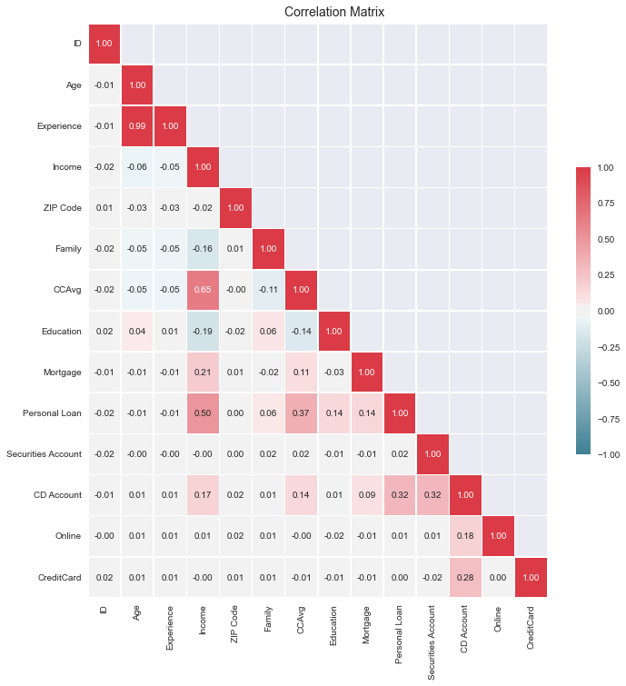

```python
# Graphical representation of the correlation

# Generate a custom diverging colormap
cmap = sns.diverging_palette(220, 10, as_cmap=True)

fig_corr, axes_corr = plt.subplots(nrows=1, ncols=1, figsize=(11,11))

# Hide the upper half of the matrix - So that we see the values only once
mask = np.zeros_like(correlation)
mask[np.triu_indices_from(mask, 1)] = True
sns.heatmap(correlation, ax=axes_corr,  linewidths=.5, cbar_kws={"shrink": .5}, cmap=cmap, vmin=-1, annot=True, fmt=".2f", mask=mask)
fig_corr.suptitle("Correlation Matrix", fontsize=14)
plt.yticks(fontsize=10, va="center")
fig_corr.tight_layout(pad=3.5)
plt.show();
```

```python
# Let us look at the target column which is 'Personal Loan' to understand how the data is distributed amongst the various values
cust_df.groupby(["Personal Loan"]).mean()
```

| Personal Loan | ID | Age | Experience | Income | ZIP Code | Family | CCAvg | Education | Mortgage | Securities Account | CD Account | Online | CreditCard |
| --- | --- | --- | --- | --- | --- | --- | --- | --- | --- | --- | --- | --- | --- |
| 0 | 2512.165487 | 45.367257 | 20.132301 | 66.237389 | 93152.428761 | 2.373451 | 1.729009 | 1.843584 | 51.789381 | 0.102212 | 0.035841 | 0.595796 | 0.293584 |
| 1 | 2390.650000 | 45.066667 | 19.843750 | 144.745833 | 93153.202083 | 2.612500 | 3.905354 | 2.233333 | 100.845833 | 0.125000 | 0.291667 | 0.606250 | 0.297917 |

##### Observation from Mean

- Personal Loan acceptance seems to have high dependency on Higher Income, Higher CCAvg, Higher Mortgage

```python
#Calculate baseline proportion - ratio of accepted to not-accepted to identify data imbalance
prop_Y = cust_df['Personal Loan'].value_counts(normalize=True) * 100
print(prop_Y)
```

```
0    90.4
1     9.6
Name: Personal Loan, dtype: float64
```

Only 9.6% of customer accepted the campaign last time, which matches with the problem statement

#### Get data model ready

```python
# Lets prepare the data for the model

# Drop the ID column that is just a 1-1 mapping
loan_df = cust_df.drop(columns="ID")

# Experience shows a min of (-3). This could be incorrect data.
print("Number of customers with invalid years of experience : {0}".format(cust_df[cust_df["Experience"] < 0].shape[0]))

cust_with_valid_experience = cust_df[cust_df["Experience"] >= 0]
median_valid_experience = cust_with_valid_experience["Experience"].median()

print("Replacing invalid experience with Median             : {0}".format(median_valid_experience))

# Replace invalid experience with Median (20)
cust_df.loc[cust_df["Experience"] < 0, "Experience"] = median_valid_experience

print("")
print("Customer Experience -- Describe")
print(cust_df.Experience.describe())


loan_df['ZIP Code'] = loan_df['ZIP Code'].astype('category')
loan_df['Education'] = loan_df['Education'].astype('category') # Takes values 1-3
loan_df['Personal Loan'] = loan_df['Personal Loan'].astype('category') # Takes 1 or 0
loan_df['Securities Account'] = loan_df['Securities Account'].astype('category') # Takes 1 or 0
loan_df['CD Account'] = loan_df['CD Account'].astype('category') # Takes 1 or 0
loan_df['Online'] = loan_df['Online'].astype('category') # Takes 1 or 0
loan_df['CreditCard'] = loan_df['CreditCard'].astype('category') # Takes 1 or 0

experiments = {}

all_columns = loan_df.columns.difference(["Personal Loan"])
Y = loan_df[["Personal Loan"]]

# EXP1: First we will test with all columns
exp1_df = loan_df[all_columns]
experiments["Experiment 1"] = {
    "df": exp1_df,
    "description": "With all columns"
}

# EXP2: With Age, Experience and Zip Code removed
lesser_columns = all_columns.difference(["Age", "Experience", "ZIP Code"])
exp2_df = loan_df[lesser_columns]
experiments["Experiment 2"] = {
    "df": exp2_df,
    "description": "With Age, Experience and ZIP Code removed"
}

# EXP3: With Experience, Zip Code, Education and Family removed
lesser_columns = all_columns.difference(["Experience", "ZIP Code", "Education", "Family"])
exp3_df = loan_df[lesser_columns]
experiments["Experiment 3"] = {
    "df": exp3_df,
    "description": "With Experience, ZIP Code, Education and Family removed"
}
```

```
Number of customers with invalid years of experience : 52
Replacing invalid experience with Median             : 20.0

Customer Experience -- Describe
count    5000.000000
mean       20.327600
std        11.253035
min         0.000000
25%        11.000000
50%        20.000000
75%        30.000000
max        43.000000
Name: Experience, dtype: float64
```

### 3. Split the data into training and test set in the ratio of 70:30 respectively

```python
def split_data(description, df_to_use):
    print("Splitting data for                         : {0}".format(description))
    X = pd.get_dummies(df_to_use, drop_first=True)
    X_train, X_test, y_train, y_test = train_test_split(X, Y, test_size=0.30, random_state=1)
    print("Original Personal Loan Accepted Values     : {0} ({1:0.2f}%)".format(len(loan_df.loc[loan_df['Personal Loan'] == 1]), (len(loan_df.loc[loan_df['Personal Loan'] == 1])/len(loan_df.index)) * 100))
    print("Original Personal Loan Not Accepted Values : {0} ({1:0.2f}%)".format(len(loan_df.loc[loan_df['Personal Loan'] == 0]), (len(loan_df.loc[loan_df['Personal Loan'] == 0])/len(loan_df.index)) * 100))
    print("")
    print("Training Personal Loan Accepted Values     : {0} ({1:0.2f}%)".format(len(y_train[y_train['Personal Loan'] == 1]), (len(y_train[y_train['Personal Loan'] == 1])/len(y_train)) * 100))
    print("Training Personal Loan Not Accepted Values : {0} ({1:0.2f}%)".format(len(y_train[y_train['Personal Loan'] == 0]), (len(y_train[y_train['Personal Loan'] == 0])/len(y_train)) * 100))
    print("")
    print("Test Personal Loan Accepted Values         : {0} ({1:0.2f}%)".format(len(y_test[y_test['Personal Loan'] == 1]), (len(y_test[y_test['Personal Loan'] == 1])/len(y_test)) * 100))
    print("Test Personal Loan Not Accepted Values     : {0} ({1:0.2f}%)".format(len(y_test[y_test['Personal Loan'] == 0]), (len(y_test[y_test['Personal Loan'] == 0])/len(y_test)) * 100))
    return (X_train, X_test, y_train, y_test)
```

### 4. Use Logistic Regression model to predict the number of a customers buying personal loans. Print all the metrics related for evaluating the model performance

```python
def create_confusion_matrix(axs, row, pos, description, actual, predicted, training_accuracy, testing_accuracy, precision, recall, f1_score, roc_auc_score):
    if axs.ndim > 1:
        axis_heat_map = axs[row][pos]
    else:
        axis_heat_map = axs[pos]

    labels = ["TN","FP","FN","TP"]
    cf = confusion_matrix( actual, predicted)
    group_labels = ["{}\n\n".format(value) for value in labels]
    group_counts = ["{0:0.0f}\n\n".format(value) for value in cf.flatten()]
    group_percentages = ["{0:.2%}".format(value) for value in cf.flatten()/np.sum(cf)]
    box_labels = [f"{v1}{v2}{v3}".strip() for v1, v2, v3 in zip(group_labels,group_counts,group_percentages)]
    box_labels = np.asarray(box_labels).reshape(cf.shape[0],cf.shape[1])

    stats_text = "\n\nAccuracy(Train) = {:0.3f}\nAccuracy(Test) = {:0.3f}\nPrecision = {:0.3f}\nRecall = {:0.3f}\nF1 Score = {:0.3f}\nROC AUC Score = {:0.3f}\n".format(training_accuracy, testing_accuracy, precision, recall, f1_score, roc_auc_score)

    heatmap = sns.heatmap(cf, annot=box_labels, annot_kws={"size": 14}, linewidths=0.5, linecolor='w', fmt="", cmap="Oranges", cbar=False, xticklabels="auto", yticklabels="auto", ax=axis_heat_map, square=True)
    axis_heat_map.set_title(description, fontsize=14)
    axis_heat_map.set_ylabel("Actual", fontsize=14)
    axis_heat_map.set_xlabel("Predicted" + stats_text, fontsize=14)
    axis_heat_map.set_xticklabels(axis_heat_map.get_xticklabels(), rotation = 45, fontsize = 10)
    axis_heat_map.set_yticklabels(axis_heat_map.get_yticklabels(), rotation = 25, fontsize = 10)

    return_list = [value for value in cf.flatten()]
    return return_list


def log_regression(axs, row, pos, description, df_to_use, log_reg_params):
    print("******************************** " + description + " ******************************************************")
    print("")
    logreg = LogisticRegression(**log_reg_params)
    X_train, X_test, y_train, y_test = split_data(description, df_to_use)

    logreg.fit(X_train, y_train)
    y_predict = logreg.predict(X_test)
    training_accuracy = logreg.score(X_train,y_train)
    testing_accuracy = logreg.score(X_test, y_test)
    precision = precision_score(y_test,y_predict)
    recall = recall_score(y_test,y_predict)
    f1score = f1_score(y_test,y_predict)
    rocscore = roc_auc_score(y_test,y_predict)

    cf_list = create_confusion_matrix(axs, row, pos, description, y_test, y_predict, training_accuracy, testing_accuracy, precision, recall, f1score, rocscore)

    return_list = [training_accuracy, testing_accuracy, precision, recall, f1score, rocscore]
    return_list = ["{:0.3f}".format(value) for value in return_list]
    return_list = cf_list + return_list
    return_list.insert(0, description)

    print("")
    print("********************************************************************************************************")


    return [X_train, X_test, y_train, y_test, logreg, y_predict, return_list]
```

```
******************************** With all columns ******************************************************

Splitting data for                         : With all columns
Original Personal Loan Accepted Values     : 480 (9.60%)
Original Personal Loan Not Accepted Values : 4520 (90.40%)

Training Personal Loan Accepted Values     : 331 (9.46%)
Training Personal Loan Not Accepted Values : 3169 (90.54%)

Test Personal Loan Accepted Values         : 149 (9.93%)
Test Personal Loan Not Accepted Values     : 1351 (90.07%)

******************************** With Age, Experience and ZIP Code removed ******************************************************

Splitting data for                         : With Age, Experience and ZIP Code removed
Original Personal Loan Accepted Values     : 480 (9.60%)
Original Personal Loan Not Accepted Values : 4520 (90.40%)

Training Personal Loan Accepted Values     : 331 (9.46%)
Training Personal Loan Not Accepted Values : 3169 (90.54%)

Test Personal Loan Accepted Values         : 149 (9.93%)
Test Personal Loan Not Accepted Values     : 1351 (90.07%)

******************************** With Experience, ZIP Code, Education and Family removed ******************************************************

Splitting data for                         : With Experience, ZIP Code, Education and Family removed
Original Personal Loan Accepted Values     : 480 (9.60%)
Original Personal Loan Not Accepted Values : 4520 (90.40%)

Training Personal Loan Accepted Values     : 331 (9.46%)
Training Personal Loan Not Accepted Values : 3169 (90.54%)

Test Personal Loan Accepted Values         : 149 (9.93%)
Test Personal Loan Not Accepted Values     : 1351 (90.07%)
```

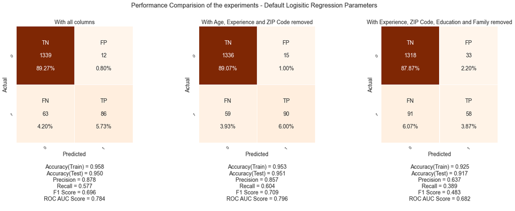

```python
default_logreg_params = {'C': 1.0, 'class_weight': None, 'dual': False, 'fit_intercept': True, 'intercept_scaling': 1, 'l1_ratio': None, 'max_iter': 100, 'multi_class': 'auto', 'n_jobs': None, 'penalty': 'l2', 'random_state': None, 'solver': 'lbfgs', 'tol': 0.0001, 'verbose': 0, 'warm_start': False}

num_plots = len(experiments.items())
total_cols = 3
total_rows = 1
fig_conf, axs = plt.subplots(nrows=total_rows, ncols=total_cols, figsize=(20,7))

exp_result = {}
all_results = {}
for i, (exp_k, exp_v) in enumerate(experiments.items()):
    row = i//total_cols
    pos = i % total_cols
    exp_data = log_regression(axs, row, pos, exp_v["description"], exp_v["df"], default_logreg_params)
    exp_result[i] = exp_data[6]
    all_results[i] = exp_data

fig_conf.tight_layout(pad=3.5)
fig_conf.suptitle("Performance Comparision of the experiments - Default Logisitic Regression Parameters", fontsize=16, y=1.05)
plt.show();
```

##### Discussion on Confusion Matrix Terms

- True Positive (TP) (Predicted = 1, Actual = 1)

  Predict that the customer will take the Personal Loan, and they actually took it
- False Positive (FP) (Predicted = 1, Actual = 0)

  Predict that the customer will take the Personal Loan, but they did not take it
- True Negative (TN) (Predicted = 0, Actual = 0)

  Predict that the customer will not take the Personal Loan, and they did not take it.
- False Negative (FN) (Predicted = 0, Actual = 1)

  Predict that the customer will not take the Personal Loan, but they actually took it. This is where the bank will loose money on missed oppotunity.

```python
exp_result_df = pd.DataFrame.from_dict(exp_result, orient="index", columns=["Description", "TN","FP","FN","TP", "Training Accuracy", "Testing Accuracy", "Precision", "Recall", "F1 Score", "ROC AUC Score"])
display(HTML(exp_result_df.to_html()))
```

|  | Description | TN | FP | FN | TP | Training Accuracy | Testing Accuracy | Precision | Recall | F1 Score | ROC AUC Score |
| --- | --- | --- | --- | --- | --- | --- | --- | --- | --- | --- | --- |
| 0 | With all columns | 1339 | 12 | 63 | 86 | 0.958 | 0.950 | 0.878 | 0.577 | 0.696 | 0.784 |
| 1 | With Age, Experience and ZIP Code removed | 1336 | 15 | 59 | 90 | 0.953 | 0.951 | 0.857 | 0.604 | 0.709 | 0.796 |
| 2 | With Experience, ZIP Code, Education and Family removed | 1318 | 33 | 91 | 58 | 0.925 | 0.917 | 0.637 | 0.389 | 0.483 | 0.682 |

##### Observation

Based on the above experiment, we see that the model **With Age, Experience and ZIP Code removed** performs better based on all the important performance metrics like:

- Higher Accuracy for Testing data
- Higher Recall and Good Precision
- Higher F1 Score
- Higher ROC AUC Score.

So we will select this model for further analysis.

The model predictions are:

- TP = 90 (predict 90 customers will take the loan and they did take the loan)
- FN = 59 (predict 59 customers will not take the loan, but they took the loan and this is where the bank will loose money)
- FP = 15 (predict 15 customers will take the loan, but they did not.)
- TN = 1336 (predict 1336 customer will not take the loan and they did not)

##### Important Metric

If the bank fails to reach out to a customer who will take the Personal Loan, the customer continues being a depositor and the bank has to keep paying them interest. So bank has to take measure to ensure more people take the Personal Loan, so that the bank can get more interest.

Since the bank stands to loose money if the FN goes up, our goal should then be to reduce FN. Which is achieved by **improving Recall** (Total Positive Rate)

So for any further performance improvement, **Recall** will be used a measure

```python
X_train, X_test, y_train, y_test, model, y_predict, return_list = all_results[1]

logit = sm.Logit(y_train, sm.add_constant(X_train))
lg = logit.fit()
```

```
Optimization terminated successfully.
         Current function value: 0.114155
         Iterations 9
```

```python
lg.summary()
```

Logit Regression Results

| Dep. Variable: | Personal Loan | No. Observations: | 3500 |
| --- | --- | --- | --- |
| Model: | Logit | Df Residuals: | 3489 |
| Method: | MLE | Df Model: | 10 |
| Date: | Fri, 10 Jul 2020 | Pseudo R-squ.: | 0.6353 |
| Time: | 20:53:10 | Log-Likelihood: | -399.54 |
| converged: | True | LL-Null: | -1095.5 |
| Covariance Type: | nonrobust | LLR p-value: | 5.751e-293 |

|  | coef | std err | z | P>\|z\| | [0.025 | 0.975] |
| --- | --- | --- | --- | --- | --- | --- |
| const | -13.1752 | 0.696 | -18.917 | 0.000 | -14.540 | -11.810 |
| CCAvg | 0.2070 | 0.053 | 3.870 | 0.000 | 0.102 | 0.312 |
| Family | 0.6465 | 0.096 | 6.746 | 0.000 | 0.459 | 0.834 |
| Income | 0.0588 | 0.004 | 16.527 | 0.000 | 0.052 | 0.066 |
| Mortgage | 0.0010 | 0.001 | 1.366 | 0.172 | -0.000 | 0.002 |
| CD Account_1 | 3.8511 | 0.425 | 9.059 | 0.000 | 3.018 | 4.684 |
| CreditCard_1 | -1.0691 | 0.260 | -4.115 | 0.000 | -1.578 | -0.560 |
| Education_2 | 3.9003 | 0.326 | 11.953 | 0.000 | 3.261 | 4.540 |
| Education_3 | 4.0278 | 0.321 | 12.533 | 0.000 | 3.398 | 4.658 |
| Online_1 | -0.6621 | 0.200 | -3.314 | 0.001 | -1.054 | -0.271 |
| Securities Account_1 | -1.1614 | 0.400 | -2.901 | 0.004 | -1.946 | -0.377 |

Possibly complete quasi-separation: A fraction 0.11 of observations can be  
perfectly predicted. This might indicate that there is complete  
quasi-separation. In this case some parameters will not be identified.

##### Interpretation of Pseudo R^2

A pseudo R^2 of 63.5% indicates that 63.5% of the uncertainty of the intercept only model is explained by the full model

```python
# Calculate the odds ratio from the coef using the formula odds ratio=exp(coef)

# Calculate the probability from the odds ratio using the formula probability = odds / (1+odds)

#Calculate Odds Ratio, probability
##create a data frame to collate Odds ratio, probability and p-value of the coef
lgcoef = pd.DataFrame(lg.params, columns=['coef'])
lgcoef.loc[:, "Odds_ratio"] = np.exp(lgcoef.coef)
lgcoef['probability'] = lgcoef['Odds_ratio']/(1+lgcoef['Odds_ratio'])
lgcoef['pval']=lg.pvalues
```

```python
lgcoef = lgcoef.sort_values(by="Odds_ratio", ascending=False)
display(HTML(lgcoef.to_html()))
```

|  | coef | Odds_ratio | probability | pval |
| --- | --- | --- | --- | --- |
| Education_3 | 4.027801 | 56.137303 | 0.982498 | 4.944380e-36 |
| Education_2 | 3.900279 | 49.416244 | 0.980165 | 6.299796e-33 |
| CD Account_1 | 3.851054 | 47.042621 | 0.979185 | 1.321503e-19 |
| Family | 0.646511 | 1.908869 | 0.656224 | 1.522642e-11 |
| CCAvg | 0.207012 | 1.229998 | 0.551569 | 1.088717e-04 |
| Income | 0.058838 | 1.060603 | 0.514705 | 2.342451e-61 |
| Mortgage | 0.000979 | 1.000980 | 0.500245 | 1.719321e-01 |
| Online_1 | -0.662055 | 0.515790 | 0.340278 | 9.192155e-04 |
| CreditCard_1 | -1.069105 | 0.343316 | 0.255573 | 3.871156e-05 |
| Securities Account_1 | -1.161366 | 0.313058 | 0.238419 | 3.716143e-03 |
| const | -13.175192 | 0.000002 | 0.000002 | 8.292265e-80 |

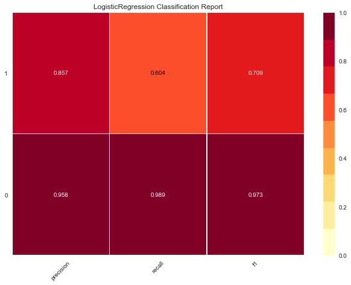

```python
viz = ClassificationReport(model, size=(640, 480))
viz.fit(X_train, y_train)
viz.score(X_test, y_test)
viz.show();
```

##### Observation

- **Precision** and **Recall** for predicting if a person will *not* take a Personal Loan is above 95% which is good.

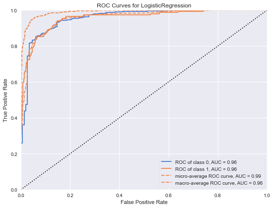

```python
roc = ROCAUC(model, size=(640, 480))
roc.fit(X_train, y_train)
roc.score(X_test, y_test)
roc.show();
```

### 5. Give your reasoning on how can the model perform better?

```python
# The current model's parameters are
model.get_params()

# This is the default as we used the default Logistic Regression Model
```

```
{'C': 1.0,
 'class_weight': None,
 'dual': False,
 'fit_intercept': True,
 'intercept_scaling': 1,
 'l1_ratio': None,
 'max_iter': 100,
 'multi_class': 'auto',
 'n_jobs': None,
 'penalty': 'l2',
 'random_state': None,
 'solver': 'lbfgs',
 'tol': 0.0001,
 'verbose': 0,
 'warm_start': False}
```

To improve the performance, once can vary the Hyper Parameters of the Logistic Regression Model and figure out what set of parameters gives better results

For this, we will leverage **GridSearchCV**

```python
param_grid = [{'solver': ['newton-cg','lbfgs','liblinear','sag','saga'], 'C': [0.01,0.1,0.25,0.5,0.75,1],
              'class_weight':['balanced'], 'penalty':['l2']}]
grid_search = GridSearchCV(LogisticRegression(),param_grid,cv=5, n_jobs=-1, verbose=0, scoring='precision')
```

```python
grid_search.fit(X_train,y_train)
```

```
GridSearchCV(cv=5, estimator=LogisticRegression(), n_jobs=-1,
             param_grid=[{'C': [0.01, 0.1, 0.25, 0.5, 0.75, 1],
                          'class_weight': ['balanced'], 'penalty': ['l2'],
                          'solver': ['newton-cg', 'lbfgs', 'liblinear', 'sag',
                                     'saga']}],
             scoring='precision')
```

```python
grid_search.best_estimator_
```

```
LogisticRegression(C=1, class_weight='balanced', solver='newton-cg')
```

```
******************************** With Age, Experience and ZIP Code removed ******************************************************

Splitting data for                         : With Age, Experience and ZIP Code removed
Original Personal Loan Accepted Values     : 480 (9.60%)
Original Personal Loan Not Accepted Values : 4520 (90.40%)

Training Personal Loan Accepted Values     : 331 (9.46%)
Training Personal Loan Not Accepted Values : 3169 (90.54%)

Test Personal Loan Accepted Values         : 149 (9.93%)
Test Personal Loan Not Accepted Values     : 1351 (90.07%)
```

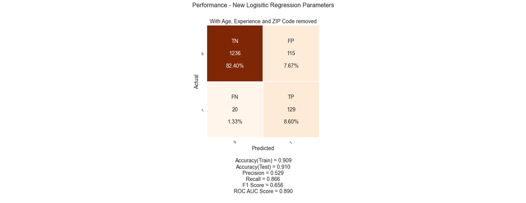

```python
# default_logreg_params = {'C': 1.0, 'class_weight': None, 'dual': False, 'fit_intercept': True, 'intercept_scaling': 1, 'l1_ratio': None, 'max_iter': 100, 'multi_class': 'auto', 'n_jobs': None, 'penalty': 'l2', 'random_state': None, 'solver': 'lbfgs', 'tol': 0.0001, 'verbose': 0, 'warm_start': False}

new_log_reg_params = {'C': 1.0, 'class_weight': 'balanced', 'dual': False, 'fit_intercept': True, 'intercept_scaling': 1, 'l1_ratio': None, 'max_iter': 100, 'multi_class': 'auto', 'n_jobs': None, 'penalty': 'l2', 'random_state': None, 'solver': 'newton-cg', 'tol': 0.0001, 'verbose': 0, 'warm_start': False}

total_cols = 3
total_rows = 1
fig_conf, axs = plt.subplots(nrows=total_rows, ncols=total_cols, figsize=(20,7))
exp_result = {}
all_results = {}
exp_v = experiments["Experiment 2"]

row = 0
pos = 1
exp_data = log_regression(axs, row, pos, exp_v["description"], exp_v["df"], new_log_reg_params)

axs[0].set_axis_off()
axs[2].set_axis_off()
fig_conf.tight_layout(pad=3.5)
fig_conf.suptitle("Performance - New Logisitic Regression Parameters", fontsize=16, y=1.05)
plt.show();
```

```python
X_train, X_test, y_train, y_test, model, y_predict, return_list = exp_data
exp_result[0] = exp_data[6]
new_model_1_df = pd.DataFrame.from_dict(exp_result, orient="index", columns=["Description", "TN","FP","FN","TP", "Training Accuracy", "Testing Accuracy", "Precision", "Recall", "F1 Score", "ROC AUC Score"])
```

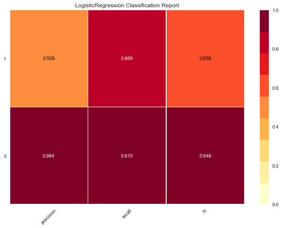

```python
viz = ClassificationReport(model, size=(640, 480))
viz.fit(X_train, y_train)
viz.score(X_test, y_test)
viz.show();
```

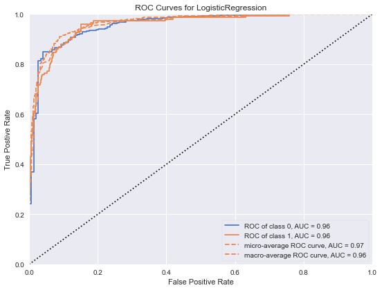

```python
roc = ROCAUC(model, size=(640, 480))
roc.fit(X_train, y_train)
roc.score(X_test, y_test)
roc.show();
```

##### Observation

Based on the requirement of reducing FN and hence improving the **Recall**, this model has done just that

- FN has reduced from 59 --> 20
- **Recall** for predicting that a customer will take Personal Loan has increased from 0.604 --> 0.866
- Train and Test Accuracy are almost same, meaning there is no overfit/underfit issue

In this model, we did a grid search to find the best combination using **Precision** as the score. Now lets try to optimize this for **Recall**

```python
param_grid = [{'solver': ['newton-cg','lbfgs','liblinear','sag','saga'], 'C': [0.01,0.1,0.25,0.5,0.75,1],
              'class_weight':['balanced'], 'penalty':['l2']}]
grid_search = GridSearchCV(LogisticRegression(),param_grid,cv=5, n_jobs=-1, verbose=0, scoring='recall')
```

```python
grid_search.fit(X_train,y_train)
```

```
GridSearchCV(cv=5, estimator=LogisticRegression(), n_jobs=-1,
             param_grid=[{'C': [0.01, 0.1, 0.25, 0.5, 0.75, 1],
                          'class_weight': ['balanced'], 'penalty': ['l2'],
                          'solver': ['newton-cg', 'lbfgs', 'liblinear', 'sag',
                                     'saga']}],
             scoring='recall')
```

```python
grid_search.best_estimator_
```

```
LogisticRegression(C=0.01, class_weight='balanced', solver='saga')
```

```
******************************** With Age, Experience and ZIP Code removed ******************************************************

Splitting data for                         : With Age, Experience and ZIP Code removed
Original Personal Loan Accepted Values     : 480 (9.60%)
Original Personal Loan Not Accepted Values : 4520 (90.40%)

Training Personal Loan Accepted Values     : 331 (9.46%)
Training Personal Loan Not Accepted Values : 3169 (90.54%)

Test Personal Loan Accepted Values         : 149 (9.93%)
Test Personal Loan Not Accepted Values     : 1351 (90.07%)
```

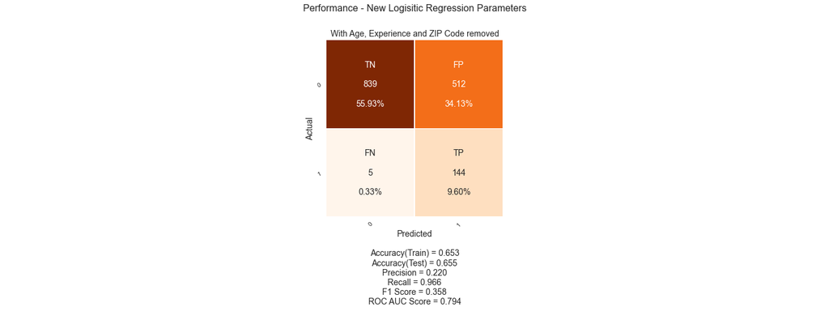

```python
# default_logreg_params = {'C': 1.0, 'class_weight': None, 'dual': False, 'fit_intercept': True, 'intercept_scaling': 1, 'l1_ratio': None, 'max_iter': 100, 'multi_class': 'auto', 'n_jobs': None, 'penalty': 'l2', 'random_state': None, 'solver': 'lbfgs', 'tol': 0.0001, 'verbose': 0, 'warm_start': False}

new_log_reg_params = {'C': 0.01, 'class_weight': "balanced", 'dual': False, 'fit_intercept': True, 'intercept_scaling': 1, 'l1_ratio': None, 'max_iter': 100, 'multi_class': 'auto', 'n_jobs': None, 'penalty': 'l2', 'random_state': None, 'solver': 'saga', 'tol': 0.0001, 'verbose': 0, 'warm_start': False}

total_cols = 3
total_rows = 1
fig_conf, axs = plt.subplots(nrows=total_rows, ncols=total_cols, figsize=(20,7))
exp_result = {}
all_results = {}
exp_v = experiments["Experiment 2"]

row = 0
pos = 1
exp_data = log_regression(axs, row, pos, exp_v["description"], exp_v["df"], new_log_reg_params)

axs[0].set_axis_off()
axs[2].set_axis_off()
fig_conf.tight_layout(pad=3.5)
fig_conf.suptitle("Performance - New Logisitic Regression Parameters", fontsize=16, y=1.05)
plt.show();
```

```python
X_train, X_test, y_train, y_test, model, y_predict, return_list = exp_data
exp_result[0] = exp_data[6]
new_model_2_df = pd.DataFrame.from_dict(exp_result, orient="index", columns=["Description", "TN","FP","FN","TP", "Training Accuracy", "Testing Accuracy", "Precision", "Recall", "F1 Score", "ROC AUC Score"])
```

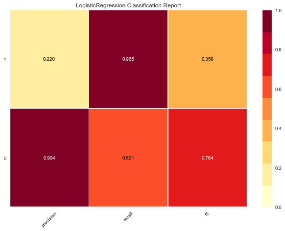

```python
viz = ClassificationReport(model, size=(640, 480))
viz.fit(X_train, y_train)
viz.score(X_test, y_test)
viz.show();
```

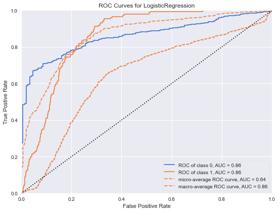

```python
roc = ROCAUC(model, size=(640, 480))
roc.fit(X_train, y_train)
roc.score(X_test, y_test)
roc.show();
```

##### Observation

We notice that this model performed much better in terms of improving the **Recall** Based on the requirement of reducing FN and hence improving the **Recall**, this model has done just that

- FN has reduced from 59 --> 5
- **Recall** for predicting that a customer will take Personal Loan has increased from 0.604 --> 0.966
- Train and Test Accuracy are almost same, meaning there is no overfit/underfit issue

##### Reasoning Consideration

The following hyper paramters were modified to get better performance

- **C** : Inverse of regularization strength - Regularization is applied to penalize the increasing of magnitude of the parameter values to reduce overfitting. Especially when we have a lot of independent variables but sparse data, then the model tries to overfit. To reduce this, penalty is applied. C captures this information. So basically if there is very little data and too many parameters, then there is a possibility of overfitting. So we should make sure we have sufficiently large dataset.
- **class_weight**: Balances the weight assigned to the classes. Setting to "balanced" makes sure, the value of "y" is used to auto adjust the weights.
- **solver**: The algorithm used in the optimization problem. For small datasets, ‘liblinear’ is a good choice, whereas ‘sag’ and ‘saga’ are faster for large ones.‘newton-cg’, ‘lbfgs’, ‘sag’ and ‘saga’ handle L2 or no penalty. ‘liblinear’ and ‘saga’ also handle L1 penalty

Ideally, to get a good fit and good performance

- We should have sufficiently large dataset with balanced classification. Here we had only 9.6% of customers who take Personal Loan.
- Based on the size of dataset, we need to vary the *solver*, *C* and *class_weight* to see what combination gives better performance for the metric of choice.
- Identifying the metric that matters the most is important. Is it **Recall** or **Precision** or both (**F1Score**). Based on this the parameters can be tweaked and tried again, until we get better performance

### 6. Give Business understanding of your model

- The bank is obligated to giving out interest to those customers who are depositors.
- If the bank does nothing, it has to keep paying interest.
- By having a customer take a Personal Loan, the bank stands to gain interest for the loan, from those customers.
- So with more number of customers taking Personal Loan, the bank will get more interest and hence save money that it pays out in interest to depositors.

So with the model, the bank aims to identify those customers who have the potential of taking Personal Loan

From the confusion matrix, we understand the following:

- True Positive (TP) (Predicted = 1, Actual = 1)

  Predict that the customer will take the Personal Loan, and they actually took it
- False Positive (FP) (Predicted = 1, Actual = 0)

  Predict that the customer will take the Personal Loan, but they did not take it
- True Negative (TN) (Predicted = 0, Actual = 0)

  Predict that the customer will not take the Personal Loan, and they did not take it.
- False Negative (FN) (Predicted = 0, Actual = 1)

  Predict that the customer will not take the Personal Loan, but they actually took it. This is where the bank will loose money on missed oppotunity.

For every customer who potentially would take a loan, and the bank missed reaching out to them, the bank looses on interest paid. This is captured by **FN (False Negative)**

So the goal is to have a **low FN**. This translates to higher **Recall**

In terms of FP, bank will reach out to customer who will not take the loan, but thats ok. Because its not adding more loss to the bank. (May be a loss in terms of marketing budget and time). So Precision is not so important in this case.

```python
display(HTML(exp_result_df.loc[[1]].to_html()))
```

|  | Description | TN | FP | FN | TP | Training Accuracy | Testing Accuracy | Precision | Recall | F1 Score | ROC AUC Score |
| --- | --- | --- | --- | --- | --- | --- | --- | --- | --- | --- | --- |
| 1 | With Age, Experience and ZIP Code removed | 1336 | 15 | 59 | 90 | 0.953 | 0.951 | 0.857 | 0.604 | 0.709 | 0.796 |

The original model came up with a **Recall** of 0.604. And it has an **FN** of 59

```python
lgcoef
```

|  | coef | Odds_ratio | probability | pval |
| --- | --- | --- | --- | --- |
| Education_3 | 4.027801 | 56.137303 | 0.982498 | 4.944380e-36 |
| Education_2 | 3.900279 | 49.416244 | 0.980165 | 6.299796e-33 |
| CD Account_1 | 3.851054 | 47.042621 | 0.979185 | 1.321503e-19 |
| Family | 0.646511 | 1.908869 | 0.656224 | 1.522642e-11 |
| CCAvg | 0.207012 | 1.229998 | 0.551569 | 1.088717e-04 |
| Income | 0.058838 | 1.060603 | 0.514705 | 2.342451e-61 |
| Mortgage | 0.000979 | 1.000980 | 0.500245 | 1.719321e-01 |
| Online_1 | -0.662055 | 0.515790 | 0.340278 | 9.192155e-04 |
| CreditCard_1 | -1.069105 | 0.343316 | 0.255573 | 3.871156e-05 |
| Securities Account_1 | -1.161366 | 0.313058 | 0.238419 | 3.716143e-03 |
| const | -13.175192 | 0.000002 | 0.000002 | 8.292265e-80 |

After achieving the desired Recall we can deploy the model for practical use. As in the bank now can predict who is take a Personal Loan. They can use the model for upcoming campaign.